# Sarajava roads for ADMS modelling

James David Smith

Import a 2km and 10km grid file for Europe CMAQ cities. The 2km grid file has a domain name in it, but the 10km does not, so use the 2km grid to remove data from the 10km grid that we are not interested in.

[figure not shown]

Now download the data for the domain by road type, harmonise, then join them all together into one road file.

Join the CMAQ 10km file so we can see which cell each road is in.

Of the data we have downloaded from OSM, 13713 rows have no lane data (95%). So we fill that in as below.

```r
grid_roads[grid_roads$highway == 'primary'          & is.na(grid_roads$lanes),'lanes'] <- 2
grid_roads[grid_roads$highway == 'primary link'     & is.na(grid_roads$lanes),'lanes'] <- 2
grid_roads[grid_roads$highway == 'secondary'        & is.na(grid_roads$lanes),'lanes'] <- 2
grid_roads[grid_roads$highway == 'motorway'         & is.na(grid_roads$lanes),'lanes'] <- 3
grid_roads[grid_roads$highway == 'motorway link'    & is.na(grid_roads$lanes),'lanes'] <- 3
grid_roads[grid_roads$highway == 'trunk'            & is.na(grid_roads$lanes),'lanes'] <- 3
grid_roads[grid_roads$highway == 'trunk link'       & is.na(grid_roads$lanes),'lanes'] <- 3
grid_roads[grid_roads$highway == 'tertiary'         & is.na(grid_roads$lanes),'lanes'] <- 2
grid_roads[grid_roads$highway == 'residential'      & is.na(grid_roads$lanes),'lanes'] <- 2
grid_roads[grid_roads$highway == 'service'          & is.na(grid_roads$lanes),'lanes'] <- 2
grid_roads[grid_roads$highway == 'unclassified'     & is.na(grid_roads$lanes),'lanes'] <- 2
```

Of the data we have downloaded from OSM, 13566 rows have no speed limit data (94%). So we also fill that in as follows.

```r
grid_roads[grid_roads$highway == 'primary'          & is.na(grid_roads$maxspeed),'maxspeed'] <- 30
grid_roads[grid_roads$highway == 'primary link'     & is.na(grid_roads$maxspeed),'maxspeed'] <- 30
grid_roads[grid_roads$highway == 'secondary'        & is.na(grid_roads$maxspeed),'maxspeed'] <- 30
grid_roads[grid_roads$highway == 'motorway'         & is.na(grid_roads$maxspeed),'maxspeed'] <- 70
grid_roads[grid_roads$highway == 'motorway link'    & is.na(grid_roads$maxspeed),'maxspeed'] <- 70
grid_roads[grid_roads$highway == 'trunk'            & is.na(grid_roads$maxspeed),'maxspeed'] <- 40
grid_roads[grid_roads$highway == 'trunk link'       & is.na(grid_roads$maxspeed),'maxspeed'] <- 40
grid_roads[grid_roads$highway == 'tertiary'         & is.na(grid_roads$maxspeed),'maxspeed'] <- 30
grid_roads[grid_roads$highway == 'residential'      & is.na(grid_roads$maxspeed),'maxspeed'] <- 30
grid_roads[grid_roads$highway == 'service'          & is.na(grid_roads$maxspeed),'maxspeed'] <- 30
grid_roads[grid_roads$highway == 'unclassified'     & is.na(grid_roads$maxspeed),'maxspeed'] <- 30
```

of the data, 87% has no entry or an ambigious entry in the oneway column, so if the entry isn’t ‘yes’ or ‘no, presume that the default is ’no’, and fill that in.

```r
grid_roads[!(grid_roads$oneway %in% c('yes','no')),'oneway'] <- 'no'
```

The final roads for the domain look like this

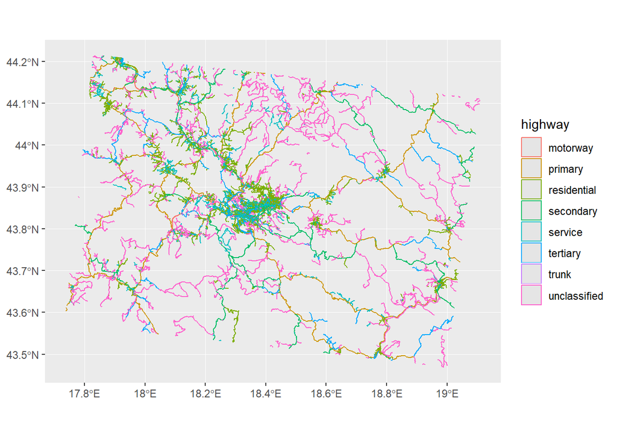

And the data is in this format

|  | osm_id | highway | lanes | maxspeed | oneway | Id | CMAQID | Xlcc | Ylcc | X_INDEX | Y_INDEX |
| --- | --- | --- | --- | --- | --- | --- | --- | --- | --- | --- | --- |
| 33188952 | 33188952 | primary | 2 | 30 | no | 0 | 52880 | 610000 | -870000 | 232 | 109 |
| 155874982 | 155874982 | primary | 2 | 30 | no | 0 | 52880 | 610000 | -870000 | 232 | 109 |
| 220276621 | 220276621 | primary | 2 | 30 | yes | 0 | 52880 | 610000 | -870000 | 232 | 109 |
| 220276634 | 220276634 | primary | 2 | 30 | yes | 0 | 52880 | 610000 | -870000 | 232 | 109 |
| 222962989 | 222962989 | primary | 2 | 50 | no | 0 | 52880 | 610000 | -870000 | 232 | 109 |
| 222962990 | 222962990 | primary | 2 | 30 | no | 0 | 52880 | 610000 | -870000 | 232 | 109 |